# Storm Data Analysis Across United States: What Events are Accountable for Population Health and Economic Losses?

Shuai

11/23/2016

## Synopsis

The Nationa Weather Service (NWS) and National Oceanic & Atmospheric Administration (NOAA) together prepared the storm database for analyzing how natural disasters caused fatal injuries, property damages and crop damages. The records in this database is ranged from 1950 to 2011. Each record contains important information such as location, disater type, start time, end time, loss on property and crop damages, count on fatalities and injuries. Totally Over 900k records are included in the analysis.

This analysis focuses on answering two questions: 1) what type of disasters caused most counts of fatalities and injuries 2) what type of disasters caused most damanages in terms of economic measures. Results show that Tornado is most harmful to population health; it also caused most damages in terms of economic consequence.

Results suggest more research efforts should put on prediction and preparation for Tornado events.

## Data Processing

There are several steps we would like to follow:  
1. download and save the data as ‘stormData.csv.bz2’.

```r
data_link<-"https://d396qusza40orc.cloudfront.net/repdata%2Fdata%2FStormData.csv.bz2"
if (!file.exists("stormData.csv.bz2")){
download.file(data_link,destfile = 'stormData.csv.bz2')
}
```

2. The extracted csv file is as “stormData.csv”. read the csv into data frame. Use data.table’s fread() function to enable high efficiency csv reading.

```r
library(data.table)
library(R.utils)
if (!file.exists("stormData.csv")) {
bunzip2("stormData.csv.bz2", "stormData.csv", remove = FALSE, skip = TRUE)
} else {
  print("file is already downloaded!")
}
```

```
## [1] "file is already downloaded!"
```

```r
raw_data<-fread("stormData.csv",header=T)
```

```
##
Read 0.0% of 967216 rows
Read 30.0% of 967216 rows
Read 48.6% of 967216 rows
Read 61.0% of 967216 rows
Read 77.5% of 967216 rows
Read 83.7% of 967216 rows
Read 902297 rows and 37 (of 37) columns from 0.523 GB file in 00:00:09
```

3. Perform exploratory data analysis. Use summary() function to explore parameters.

```r
summary(raw_data)
```

```
##     STATE__       BGN_DATE           BGN_TIME          TIME_ZONE
##  Min.   : 1.0   Length:902297      Length:902297      Length:902297
##  1st Qu.:19.0   Class :character   Class :character   Class :character
##  Median :30.0   Mode  :character   Mode  :character   Mode  :character
##  Mean   :31.2
##  3rd Qu.:45.0
##  Max.   :95.0
##
##      COUNTY       COUNTYNAME           STATE              EVTYPE
##  Min.   :  0.0   Length:902297      Length:902297      Length:902297
##  1st Qu.: 31.0   Class :character   Class :character   Class :character
##  Median : 75.0   Mode  :character   Mode  :character   Mode  :character
##  Mean   :100.6
##  3rd Qu.:131.0
##  Max.   :873.0
##
##    BGN_RANGE          BGN_AZI           BGN_LOCATI
##  Min.   :   0.000   Length:902297      Length:902297
##  1st Qu.:   0.000   Class :character   Class :character
##  Median :   0.000   Mode  :character   Mode  :character
##  Mean   :   1.484
##  3rd Qu.:   1.000
##  Max.   :3749.000
##
##    END_DATE           END_TIME           COUNTY_END COUNTYENDN
##  Length:902297      Length:902297      Min.   :0    Mode:logical
##  Class :character   Class :character   1st Qu.:0    NA's:902297
##  Mode  :character   Mode  :character   Median :0
##                                        Mean   :0
##                                        3rd Qu.:0
##                                        Max.   :0
##
##    END_RANGE          END_AZI           END_LOCATI
##  Min.   :  0.0000   Length:902297      Length:902297
##  1st Qu.:  0.0000   Class :character   Class :character
##  Median :  0.0000   Mode  :character   Mode  :character
##  Mean   :  0.9862
##  3rd Qu.:  0.0000
##  Max.   :925.0000
##
```

[output cut: 33 more lines]

```
##  Min.   :-14451   Min.   :   0   Min.   :-14455   Length:902297
##  1st Qu.:  7247   1st Qu.:   0   1st Qu.:     0   Class :character
##  Median :  8707   Median :   0   Median :     0   Mode  :character
##  Mean   :  6940   Mean   :1452   Mean   :  3509
##  3rd Qu.:  9605   3rd Qu.:3549   3rd Qu.:  8735
##  Max.   : 17124   Max.   :9706   Max.   :106220
##                   NA's   :40
##      REFNUM
##  Min.   :     1
##  1st Qu.:225575
##  Median :451149
##  Mean   :451149
##  3rd Qu.:676723
##  Max.   :902297
##
```

4. Data Preparation.  
   To help analyze results directly related to required questions. I subset the original data into two indepndent dataset. The first question is : “Across the United States, which types of events (as indicated in the 𝙴𝚅𝚃𝚈𝙿𝙴 variable) are most harmful with respect to population health?”. In order to answer what *“EVTYPE”* are most *“harmful”* related to *“population health”*. We need to find corresponding variables that are useful. Therefore, we subset the data (using subset() function to select variables of interest). The parameters of intertest are “EVTYPE, FATALITIES, INJURIES, REFUNM”  
   4.1 Population Health Data Preparation

```r
PeopleHealth<-subset(raw_data,select=c(EVTYPE,FATALITIES,INJURIES,REFNUM))
PeopleHealthFull<-na.omit(PeopleHealth)#get full records
```

This PeopleHealthFull data is used for Results part.  
4.2 Economic Loss Data Preparation Similar to 4.1, I subset the original data into a subset with variables of interest to answer questions – “Across the United States, which types of events have the greatest economic consequences”. These variables include:PROPDMG, PROPDMGEXP, CROPDMG

```r
econData<-subset(raw_data,select=c(EVTYPE,PROPDMG,PROPDMGEXP,CROPDMG,CROPDMGEXP,REFNUM))
econDataFull<-na.omit(econData)
```

## Results

### Across the United States, which types of events (as indicated in the 𝙴𝚅𝚃𝚈𝙿𝙴 variable) are most harmful with respect to population health?

We use histogram plot to answer this question. Remember PeopleHealth data stores all information we need.

```r
altSummary<-aggregate(cbind(FATALITIES,INJURIES)~EVTYPE,PeopleHealth,FUN=sum)
library(plyr)
altSummary<-arrange(altSummary,desc(FATALITIES),desc(INJURIES))
top10Health<-head(altSummary,10)
```

Plot the top 10 event types that cause fatalites and injuries:

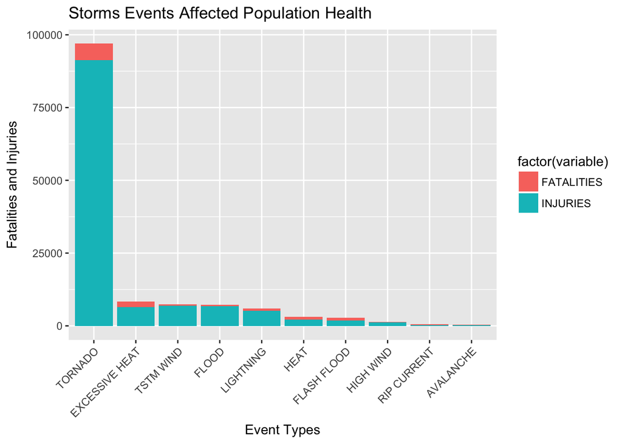

```r
library(ggplot2)
# Basic barplot by ggplot2
library(reshape2)
melted_data<-melt(top10Health,id.vars="EVTYPE")
p<-ggplot(melted_data,aes(x=reorder(EVTYPE,-value),y=value,fill=factor(variable)))+
  geom_bar(stat="identity")+
  theme(axis.text.x = element_text(angle = 45, hjust = 1))+
  xlab("Event Types")+
  ylab("Fatalities and Injuries")+
  ggtitle("Storms Events Affected Population Health")
print(p)
```

### Across the United States, which types of events have the greatest economic consequences?

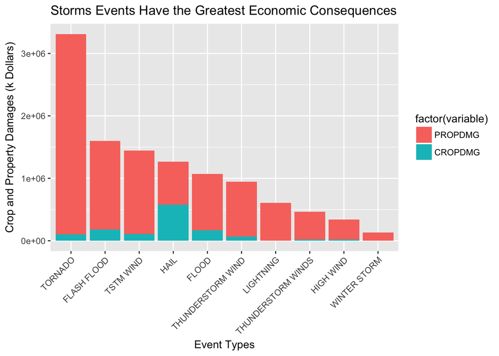

```r
summaryEcon<-aggregate(cbind(PROPDMG,CROPDMG)~EVTYPE,econDataFull,FUN=sum)
library(plyr)
summaryEcon<-arrange(summaryEcon,desc(PROPDMG))
top10Loss<-head(summaryEcon,10)
melted_loss<-melt(top10Loss,id.vars = "EVTYPE")
p<-ggplot(data=melted_loss, aes(x=reorder(EVTYPE,-value),y=value,fill=factor(variable)))+
  geom_bar(stat="identity")+
  theme(axis.text.x = element_text(angle = 45, hjust = 1))+
  xlab("Event Types")+
  ylab("Crop and Property Damages (k Dollars)")+
  ggtitle("Storms Events Have the Greatest Economic Consequences")
p
```

## Conclusion

Base on analysis between storm event types versus counts of fatalities and injuries, and event types versus damages to properties and corps, we suggest more research efforts should go towards Tornado events.

Regarding mangers who need weather information for crop damages, “Hail” cost crop damages more than other event types.